# Analysis

pg611@scarletmail.rutgers.edu

2024-03-28

```r
library(psych)
library(readr)
## Warning: package 'readr' was built under R version 4.3.2
library(factoextra)
```

```r
library(FactoMineR)
## Warning: package 'FactoMineR' was built under R version 4.3.3
library(magrittr)
library(NbClust)
library(readr)
library(lattice)
library(ggplot2)
library(ggridges)
library(ggvis)
library(ggthemes)
library(cowplot)
library(gapminder)
library(gganimate)
library(dplyr)
library(tidyverse)
library(grid)
library(gridExtra)
library(RColorBrewer)
library(cluster)
library(readr)
library(factoextra)
library(magrittr)
library(NbClust)
library(ggplot2) # for visualization
library(reshape2) # for data manipulation
library(factoextra)
library(FactoMineR)
library(psych)
library(corrplot)
library(devtools)
```

# DATASET DESCRIPTION :

# DATA DICTIONARY

Here’s the data dictionary for the dataset:

ID: Unique identifier for each student.

Instagram Usage: The amount of time spent by each student on Instagram.

LinkedIn Usage: The amount of time spent by each student on LinkedIn.

Snapchat Usage: The amount of time spent by each student on Snapchat.

Twitter Usage: The amount of time spent by each student on Twitter.

Whatsapp Usage: The amount of time spent by each student on WhatsApp.

Youtube Usage: The amount of time spent by each student on YouTube.

OTT (Over-the-top media service) Usage: The amount of time spent by each student on OTT platforms.

Reddit Usage: The amount of time spent by each student on Reddit.

Trouble_falling_asleep: A variable indicating whether the student experiences trouble falling asleep. It may have values like “Yes” or “No”.

```r
sc_dataset <- read.csv("/Users/parul/OneDrive/Desktop/MVA/Midterm_Final.csv", row.names=1)
```

The correlation matrix provides insight into the relationships between different variables. In this case, the correlation matrix displays the correlations between different social media usage measurements (LinkedIn, Snapchat, Twitter, WhatsApp, Youtube, OTT, Reddit).

```r
#Get the Correlations between the measurements

correlation_matrix <- cor(sc_dataset[,1:8][-1])
correlation_matrix
```

```
##                LinkedIn.Usage Snapchat.Usage Twitter.Usage Whatsapp.Usage
## LinkedIn.Usage     1.00000000     0.32544073   -0.09335105     0.22579139
## Snapchat.Usage     0.32544073     1.00000000   -0.14890053    -0.13331331
## Twitter.Usage     -0.09335105    -0.14890053    1.00000000    -0.48917552
## Whatsapp.Usage     0.22579139    -0.13331331   -0.48917552     1.00000000
## Youtube.Usage      0.44270784     0.22847683   -0.18199276     0.20275645
## OTT                0.18555802     0.46736641    0.58200787    -0.22148735
## Reddit            -0.02236945    -0.03059025    0.17724490    -0.09878051
##                Youtube.Usage        OTT      Reddit
## LinkedIn.Usage    0.44270784  0.1855580 -0.02236945
## Snapchat.Usage    0.22847683  0.4673664 -0.03059025
## Twitter.Usage    -0.18199276  0.5820079  0.17724490
## Whatsapp.Usage    0.20275645 -0.2214874 -0.09878051
## Youtube.Usage     1.00000000  0.1664032  0.02470231
## OTT               0.16640319  1.0000000  0.21644990
## Reddit            0.02470231  0.2164499  1.00000000
```

• A correlation coefficient close to 1 indicates a strong positive relationship, while a coefficient close to -1 indicates a strong negative relationship.

• A correlation coefficient close to 0 indicates no linear relationship between the variables.

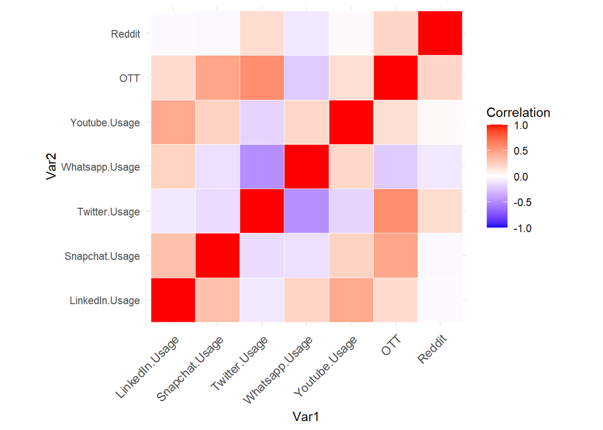

```r
# Visualize correlation matrix
ggplot(melt(correlation_matrix), aes(Var1, Var2, fill = value)) +
  geom_tile(color = "white") +
  scale_fill_gradient2(low = "blue", high = "red", mid = "white",
                       midpoint = 0, limit = c(-1,1), space = "Lab",
                       name="Correlation") +
  theme_minimal() +
  theme(axis.text.x = element_text(angle = 45, vjust = 1, size = 10, hjust = 1)) +
  coord_fixed()
```

For Example :

LinkedIn.Usage vs. Snapchat.Usage: A moderate positive correlation (0.3254), suggesting that as LinkedIn usage increases, Snapchat usage tends to increase as well, but not strongly.

LinkedIn.Usage vs. Twitter.Usage: A weak negative correlation (-0.0934), indicating a slight negative relationship between LinkedIn and Twitter usage.

LinkedIn.Usage vs. Whatsapp.Usage: A moderate positive correlation (0.2258), indicating a moderate tendency for LinkedIn and WhatsApp usage to increase together. and so on..

These correlations provide insights into the relationships between different social media usage variables, which can be further explored through principal component analysis (PCA) to identify underlying patterns and reduce the dimensionality of the data.

# PCA

• PCA helps in reducing the dimensionality of the dataset while retaining most of the variability present in the original data.

• It identifies patterns and relationships between the different social media usage metrics and potentially identifies underlying factors influencing these patterns.

• The results suggest that the first few principal components explain a significant portion of the variability in social media usage behaviors, indicating potential underlying factors driving these behaviors.

```r
sc_dataset_pca <- prcomp(sc_dataset[,1:8][,-1],scale=TRUE)
sc_dataset_pca
```

```
## Standard deviations (1, .., p=7):
## [1] 1.4211473 1.3814828 1.0017794 0.8910314 0.7896400 0.7347206 0.3331683
##
## Rotation (n x k) = (7 x 7):
##                        PC1         PC2         PC3        PC4         PC5
## LinkedIn.Usage -0.00885089  0.56540133 -0.08483248  0.3027683 -0.03546937
## Snapchat.Usage  0.21917033  0.47508909  0.45106720 -0.5389487 -0.14754147
## Twitter.Usage   0.57588658 -0.19914319 -0.09653544  0.5046274 -0.06768201
## Whatsapp.Usage -0.46717951  0.23352067 -0.31891656  0.1725100 -0.66863041
## Youtube.Usage  -0.05010655  0.53603292 -0.23067472  0.2039896  0.62197782
## OTT             0.57606069  0.26992052  0.00180323  0.1023354 -0.37180096
## Reddit          0.26005268 -0.01527768 -0.79063322 -0.5304459  0.01528377
##                        PC6         PC7
## LinkedIn.Usage  0.75518961  0.09903738
## Snapchat.Usage -0.03329285 -0.45765759
## Twitter.Usage   0.01817443 -0.59984794
## Whatsapp.Usage -0.28224882 -0.26270305
## Youtube.Usage  -0.46705897 -0.10166114
## OTT            -0.32984224  0.58119648
## Reddit          0.14712428 -0.06153332
```

```r
summary(sc_dataset_pca)
```

```
## Importance of components:
##                           PC1    PC2    PC3    PC4     PC5     PC6     PC7
## Standard deviation     1.4211 1.3815 1.0018 0.8910 0.78964 0.73472 0.33317
## Proportion of Variance 0.2885 0.2726 0.1434 0.1134 0.08908 0.07712 0.01586
## Cumulative Proportion  0.2885 0.5612 0.7045 0.8179 0.90703 0.98414 1.00000
```

• The standard deviations represent the variability captured by each principal component (PC).

• PC1 has the highest standard deviation (1.4211), followed by PC2 (1.3815), indicating that PC1 explains the most variability in the data, followed closely by PC2.

The column “Trouble_falling_asleep” likely represents a categorical variable indicating whether individuals in the dataset experience trouble falling asleep.

```r
library(factoextra)



# Eigenvalues are sdev^2
(eigen_sc_dataset <- sc_dataset_pca$sdev^2)
```

```
## [1] 2.0196597 1.9084948 1.0035619 0.7939369 0.6235313 0.5398143 0.1110011
```

```r
names(eigen_sc_dataset) <- paste("PC",1:3,sep="")
eigen_sc_dataset
```

```
##       PC1       PC2       PC3      <NA>      <NA>      <NA>      <NA>
## 2.0196597 1.9084948 1.0035619 0.7939369 0.6235313 0.5398143 0.1110011
```

```r
sumlambdas <- sum(eigen_sc_dataset)
sumlambdas
```

```
## [1] 7
```

```r
propvar <- eigen_sc_dataset/sumlambdas
propvar
```

```
##        PC1        PC2        PC3       <NA>       <NA>       <NA>       <NA>
## 0.28852281 0.27264212 0.14336599 0.11341955 0.08907590 0.07711633 0.01585730
```

```r
cumvar_sc_dataset <- cumsum(propvar)
cumvar_sc_dataset
```

```
##       PC1       PC2       PC3      <NA>      <NA>      <NA>      <NA>
## 0.2885228 0.5611649 0.7045309 0.8179505 0.9070264 0.9841427 1.0000000
```

```r
matlambdas <- rbind(eigen_sc_dataset,propvar,cumvar_sc_dataset)
rownames(matlambdas) <- c("Eigenvalues","Prop. variance","Cum. prop. variance")
round(matlambdas,4)
```

```
##                        PC1    PC2    PC3   <NA>   <NA>   <NA>   <NA>
## Eigenvalues         2.0197 1.9085 1.0036 0.7939 0.6235 0.5398 0.1110
## Prop. variance      0.2885 0.2726 0.1434 0.1134 0.0891 0.0771 0.0159
## Cum. prop. variance 0.2885 0.5612 0.7045 0.8180 0.9070 0.9841 1.0000
```

```r
summary(sc_dataset_pca)
```

```
## Importance of components:
##                           PC1    PC2    PC3    PC4     PC5     PC6     PC7
## Standard deviation     1.4211 1.3815 1.0018 0.8910 0.78964 0.73472 0.33317
## Proportion of Variance 0.2885 0.2726 0.1434 0.1134 0.08908 0.07712 0.01586
## Cumulative Proportion  0.2885 0.5612 0.7045 0.8179 0.90703 0.98414 1.00000
```

```r
sc_dataset_pca$rotation
```

```
##                        PC1         PC2         PC3        PC4         PC5
## LinkedIn.Usage -0.00885089  0.56540133 -0.08483248  0.3027683 -0.03546937
## Snapchat.Usage  0.21917033  0.47508909  0.45106720 -0.5389487 -0.14754147
## Twitter.Usage   0.57588658 -0.19914319 -0.09653544  0.5046274 -0.06768201
## Whatsapp.Usage -0.46717951  0.23352067 -0.31891656  0.1725100 -0.66863041
## Youtube.Usage  -0.05010655  0.53603292 -0.23067472  0.2039896  0.62197782
## OTT             0.57606069  0.26992052  0.00180323  0.1023354 -0.37180096
## Reddit          0.26005268 -0.01527768 -0.79063322 -0.5304459  0.01528377
##                        PC6         PC7
## LinkedIn.Usage  0.75518961  0.09903738
## Snapchat.Usage -0.03329285 -0.45765759
## Twitter.Usage   0.01817443 -0.59984794
## Whatsapp.Usage -0.28224882 -0.26270305
## Youtube.Usage  -0.46705897 -0.10166114
## OTT            -0.32984224  0.58119648
## Reddit          0.14712428 -0.06153332
```

```r
print(sc_dataset_pca)
```

```
## Standard deviations (1, .., p=7):
## [1] 1.4211473 1.3814828 1.0017794 0.8910314 0.7896400 0.7347206 0.3331683
##
## Rotation (n x k) = (7 x 7):
##                        PC1         PC2         PC3        PC4         PC5
## LinkedIn.Usage -0.00885089  0.56540133 -0.08483248  0.3027683 -0.03546937
## Snapchat.Usage  0.21917033  0.47508909  0.45106720 -0.5389487 -0.14754147
## Twitter.Usage   0.57588658 -0.19914319 -0.09653544  0.5046274 -0.06768201
## Whatsapp.Usage -0.46717951  0.23352067 -0.31891656  0.1725100 -0.66863041
## Youtube.Usage  -0.05010655  0.53603292 -0.23067472  0.2039896  0.62197782
## OTT             0.57606069  0.26992052  0.00180323  0.1023354 -0.37180096
## Reddit          0.26005268 -0.01527768 -0.79063322 -0.5304459  0.01528377
##                        PC6         PC7
## LinkedIn.Usage  0.75518961  0.09903738
## Snapchat.Usage -0.03329285 -0.45765759
## Twitter.Usage   0.01817443 -0.59984794
## Whatsapp.Usage -0.28224882 -0.26270305
## Youtube.Usage  -0.46705897 -0.10166114
## OTT            -0.32984224  0.58119648
## Reddit          0.14712428 -0.06153332
```

```r
sc_dataset_pca$x
```

```
##                 PC1         PC2         PC3         PC4          PC5
## masinl   4.97861698 -0.17942148 -0.90652361  1.33109447 -0.717663636
## peace   -0.25713788  1.14234886  0.78733501 -0.52410682  0.820482916
## Patty   -0.96973501  0.44227298 -0.21058706  0.66124884 -1.127623960
## Bunny   -0.29063834  0.12826240  0.40117331  0.02530153 -0.170410846
## tl868    0.18285125 -1.09317200 -0.23515327 -0.32329695  0.862471735
## drphy   -1.30405097  2.34846783 -1.16936167  1.46293761  0.231218688
## trave   -0.89680707 -0.24725337 -0.06717359  0.34128946  0.350737475
## 19!@s   -0.54552586  0.75109940  0.46379315 -0.40363548 -1.337030554
## yh2020  -0.03641635  2.57257883  0.48640992  0.19972711 -0.004152286
## ds2134  -0.21133248 -1.47639209  0.52527173 -0.38512273  1.367826744
## ki567    0.90334123 -1.91160852  0.60823847  0.46164535  0.489174214
## ak2001   0.86350771 -1.25925289  0.17902716  0.91121864  0.338535267
## Harvey  -0.34113532 -1.37096357  0.77544246 -0.63816900 -0.242266533
## hahah    0.24216620 -0.68259534  0.48872359  0.13104612  0.403357734
## AKIRA    0.61217989  0.06122753 -3.24063472 -2.36677200  0.129126894
## vp1234  -0.58027605  0.65894199 -0.35586754  0.49609809  1.113040330
## sss32   -1.55888205 -0.36991928 -0.66376211  0.42009781 -1.029369777
## MVA37@S -0.33358944 -0.94199342  0.68189490 -0.61292138 -0.981763836
## 2134    -1.29722215  0.46024977 -0.55992557  0.65627163  0.605864826
## 15801    1.93802375  2.80305467  1.76624046 -1.50657441 -0.014682907
## Baiqi   -1.09793805 -1.83593229  0.24543896 -0.33737790 -1.086872490
##                 PC6         PC7
## masinl  -0.24610714  0.24330977
## peace    0.40020074 -0.55770183
## Patty    1.09647741  0.38927857
## Bunny    0.76068545  0.39386939
## tl868   -0.73127111  0.36921219
## drphy   -0.65640276  0.05777668
## trave    0.28220530  0.20448264
## 19!@s   -0.11288048 -0.32337215
## yh2020   1.45407071 -0.03828212
## ds2134  -0.50552548  0.42556458
## ki567    0.67397804 -0.51918235
## ak2001   0.08315456 -0.66020631
## Harvey   0.29026889  0.21858869
## hahah    0.29531769 -0.15972036
## AKIRA    0.55090910 -0.18353990
## vp1234   0.06049703  0.29148736
## sss32   -1.56703297 -0.34127504
## MVA37@S -0.06703223  0.19232753
## 2134    -0.61384874 -0.12647497
## 15801   -1.24451373  0.05878886
## Baiqi   -0.20315029  0.06506876
```

```r
sc_datasettyp_pca <- cbind(data.frame(sc_dataset$Trouble_falling_asleep),sc_dataset_pca$x)
sc_datasettyp_pca
```

```
##         sc_dataset.Trouble_falling_asleep         PC1         PC2         PC3
## masinl                                 No  4.97861698 -0.17942148 -0.90652361
## peace                                 Yes -0.25713788  1.14234886  0.78733501
## Patty                                  No -0.96973501  0.44227298 -0.21058706
## Bunny                                  No -0.29063834  0.12826240  0.40117331
## tl868                                 Yes  0.18285125 -1.09317200 -0.23515327
## drphy                                  No -1.30405097  2.34846783 -1.16936167
## trave                                  No -0.89680707 -0.24725337 -0.06717359
## 19!@s                                 Yes -0.54552586  0.75109940  0.46379315
## yh2020                                 No -0.03641635  2.57257883  0.48640992
## ds2134                                 No -0.21133248 -1.47639209  0.52527173
## ki567                                 Yes  0.90334123 -1.91160852  0.60823847
## ak2001                                 No  0.86350771 -1.25925289  0.17902716
## Harvey                                Yes -0.34113532 -1.37096357  0.77544246
## hahah                                  No  0.24216620 -0.68259534  0.48872359
## AKIRA                                  No  0.61217989  0.06122753 -3.24063472
## vp1234                                Yes -0.58027605  0.65894199 -0.35586754
## sss32                                  No -1.55888205 -0.36991928 -0.66376211
## MVA37@S                                No -0.33358944 -0.94199342  0.68189490
## 2134                                   No -1.29722215  0.46024977 -0.55992557
## 15801                                 Yes  1.93802375  2.80305467  1.76624046
## Baiqi                                  No -1.09793805 -1.83593229  0.24543896
##                 PC4          PC5         PC6         PC7
## masinl   1.33109447 -0.717663636 -0.24610714  0.24330977
## peace   -0.52410682  0.820482916  0.40020074 -0.55770183
## Patty    0.66124884 -1.127623960  1.09647741  0.38927857
## Bunny    0.02530153 -0.170410846  0.76068545  0.39386939
## tl868   -0.32329695  0.862471735 -0.73127111  0.36921219
## drphy    1.46293761  0.231218688 -0.65640276  0.05777668
## trave    0.34128946  0.350737475  0.28220530  0.20448264
## 19!@s   -0.40363548 -1.337030554 -0.11288048 -0.32337215
## yh2020   0.19972711 -0.004152286  1.45407071 -0.03828212
## ds2134  -0.38512273  1.367826744 -0.50552548  0.42556458
## ki567    0.46164535  0.489174214  0.67397804 -0.51918235
## ak2001   0.91121864  0.338535267  0.08315456 -0.66020631
## Harvey  -0.63816900 -0.242266533  0.29026889  0.21858869
## hahah    0.13104612  0.403357734  0.29531769 -0.15972036
## AKIRA   -2.36677200  0.129126894  0.55090910 -0.18353990
## vp1234   0.49609809  1.113040330  0.06049703  0.29148736
## sss32    0.42009781 -1.029369777 -1.56703297 -0.34127504
## MVA37@S -0.61292138 -0.981763836 -0.06703223  0.19232753
## 2134     0.65627163  0.605864826 -0.61384874 -0.12647497
## 15801   -1.50657441 -0.014682907 -1.24451373  0.05878886
## Baiqi   -0.33737790 -1.086872490 -0.20315029  0.06506876
```

```r
# Means of scores
tabmeansPC <- aggregate(sc_datasettyp_pca[,2:4],by=list(Trouble_falling_asleep=sc_dataset$Trouble_falling_asleep),mean)
tabmeansPC
```

```
##   Trouble_falling_asleep         PC1         PC2        PC3
## 1                     No -0.09286722 -0.06997863 -0.2721449
## 2                    Yes  0.18573445  0.13995726  0.5442898
```

```r
tabmeansPC <- tabmeansPC[rev(order(tabmeansPC$Trouble_falling_asleep)),]
tabmeansPC
```

```
##   Trouble_falling_asleep         PC1         PC2        PC3
## 2                    Yes  0.18573445  0.13995726  0.5442898
## 1                     No -0.09286722 -0.06997863 -0.2721449
```

```r
tabfmeans <- t(tabmeansPC[,-1])
tabfmeans
```

```
##             2           1
## PC1 0.1857344 -0.09286722
## PC2 0.1399573 -0.06997863
## PC3 0.5442898 -0.27214491
```

```r
colnames(tabfmeans) <- t(as.vector(tabmeansPC[1]$Trouble_falling_asleep))
tabfmeans
```

```
##           Yes          No
## PC1 0.1857344 -0.09286722
## PC2 0.1399573 -0.06997863
## PC3 0.5442898 -0.27214491
```

```r
# Standard deviations of scores
tabsdsPC <- aggregate(sc_datasettyp_pca[,2:4],by=list(Trouble_falling_asleep=sc_dataset$Trouble_falling_asleep),sd)
tabfsds <- t(tabsdsPC[,-1])
colnames(tabfsds) <- t(as.vector(tabsdsPC[1]$Trouble_falling_asleep))
tabfsds
```

```
##           No       Yes
## PC1 1.637311 0.9292225
## PC2 1.277380 1.6709343
## PC3 1.035023 0.7111083
```

```r
t.test(PC1~sc_dataset$Trouble_falling_asleep,data=sc_datasettyp_pca)
```

```
##
##  Welch Two Sample t-test
##
## data:  PC1 by sc_dataset$Trouble_falling_asleep
## t = -0.49653, df = 18.505, p-value = 0.6254
## alternative hypothesis: true difference in means between group No and group Yes is not equal to 0
## 95 percent confidence interval:
##  -1.4551305  0.8979272
## sample estimates:
##  mean in group No mean in group Yes
##       -0.09286722        0.18573445
```

```r
t.test(PC2~sc_dataset$Trouble_falling_asleep,data=sc_datasettyp_pca)
```

```
##
##  Welch Two Sample t-test
##
## data:  PC2 by sc_dataset$Trouble_falling_asleep
## t = -0.29242, df = 9.6389, p-value = 0.7762
## alternative hypothesis: true difference in means between group No and group Yes is not equal to 0
## 95 percent confidence interval:
##  -1.817722  1.397850
## sample estimates:
##  mean in group No mean in group Yes
##       -0.06997863        0.13995726
```

```r
t.test(PC3~sc_dataset$Trouble_falling_asleep,data=sc_datasettyp_pca)
```

```
##
##  Welch Two Sample t-test
##
## data:  PC3 by sc_dataset$Trouble_falling_asleep
## t = -2.1168, df = 16.763, p-value = 0.04955
## alternative hypothesis: true difference in means between group No and group Yes is not equal to 0
## 95 percent confidence interval:
##  -1.631053919 -0.001815545
## sample estimates:
##  mean in group No mean in group Yes
##        -0.2721449         0.5442898
```

```r
## F ratio tests
var.test(PC1~sc_dataset$Trouble_falling_asleep,data=sc_datasettyp_pca)
```

```
##
##  F test to compare two variances
##
## data:  PC1 by sc_dataset$Trouble_falling_asleep
## F = 3.1047, num df = 13, denom df = 6, p-value = 0.1724
## alternative hypothesis: true ratio of variances is not equal to 1
## 95 percent confidence interval:
##   0.582607 11.190222
## sample estimates:
## ratio of variances
##           3.104724
```

```r
var.test(PC2~sc_dataset$Trouble_falling_asleep,data=sc_datasettyp_pca)
```

```
##
##  F test to compare two variances
##
## data:  PC2 by sc_dataset$Trouble_falling_asleep
## F = 0.58442, num df = 13, denom df = 6, p-value = 0.3918
## alternative hypothesis: true ratio of variances is not equal to 1
## 95 percent confidence interval:
##  0.1096665 2.1063819
## sample estimates:
## ratio of variances
##          0.5844151
```

```r
var.test(PC3~sc_dataset$Trouble_falling_asleep,data=sc_datasettyp_pca)
```

```
##
##  F test to compare two variances
##
## data:  PC3 by sc_dataset$Trouble_falling_asleep
## F = 2.1185, num df = 13, denom df = 6, p-value = 0.3654
## alternative hypothesis: true ratio of variances is not equal to 1
## 95 percent confidence interval:
##  0.3975405 7.6356211
## sample estimates:
## ratio of variances
##           2.118501
```

```r
# Levene's tests (one-sided)
library(car)
(LTPC1 <- leveneTest(PC1~sc_dataset$Trouble_falling_asleep,data=sc_datasettyp_pca))
```

```
## Levene's Test for Homogeneity of Variance (center = median)
##       Df F value Pr(>F)
## group  1  0.3743 0.5479
##       19
```

```r
(p_PC1_1sided <- LTPC1[[3]][1]/2)
```

```
## [1] 0.2739558
```

```r
(LTPC2 <- leveneTest(PC2~sc_dataset$Trouble_falling_asleep,data=sc_datasettyp_pca))
```

```
## Levene's Test for Homogeneity of Variance (center = median)
##       Df F value Pr(>F)
## group  1  0.8064 0.3804
##       19
```

```r
(p_PC2_1sided=LTPC2[[3]][1]/2)
```

```
## [1] 0.1902136
```

```r
(LTPC3 <- leveneTest(PC3~sc_dataset$Trouble_falling_asleep,data=sc_datasettyp_pca))
```

```
## Levene's Test for Homogeneity of Variance (center = median)
##       Df F value Pr(>F)
## group  1  0.3881 0.5407
##       19
```

```r
(p_PC3_1sided <- LTPC3[[3]][1]/2)
```

```
## [1] 0.2703466
```

T-tests:

T-tests have been performed to compare the means of the principal component scores between groups based on the variable “Trouble_falling_asleep” (Yes/No).

For PC1 and PC2, the p-values are greater than 0.05, suggesting that there is no significant difference in the means between the groups.

However, for PC3, the p-value is less than 0.05, indicating a significant difference in the means between the groups. Variance Homogeneity Tests:

Levene’s tests have been conducted to assess the homogeneity of variance for each principal component between the two groups.

For PC1 and PC2, the p-values are greater than 0.05, indicating that there is no significant difference in variance between the groups.

Similarly, for PC3, the p-value is also greater than 0.05, suggesting no significant difference in variance between the groups.

```r
# Different PCA Method.
res.pca <- PCA(sc_dataset[,1:8][,-1], graph = FALSE)
print(res.pca)
```

```
## **Results for the Principal Component Analysis (PCA)**
## The analysis was performed on 21 individuals, described by 7 variables
## *The results are available in the following objects:
##
##    name               description
## 1  "$eig"             "eigenvalues"
## 2  "$var"             "results for the variables"
## 3  "$var$coord"       "coord. for the variables"
## 4  "$var$cor"         "correlations variables - dimensions"
## 5  "$var$cos2"        "cos2 for the variables"
## 6  "$var$contrib"     "contributions of the variables"
## 7  "$ind"             "results for the individuals"
## 8  "$ind$coord"       "coord. for the individuals"
## 9  "$ind$cos2"        "cos2 for the individuals"
## 10 "$ind$contrib"     "contributions of the individuals"
## 11 "$call"            "summary statistics"
## 12 "$call$centre"     "mean of the variables"
## 13 "$call$ecart.type" "standard error of the variables"
## 14 "$call$row.w"      "weights for the individuals"
## 15 "$call$col.w"      "weights for the variables"
```

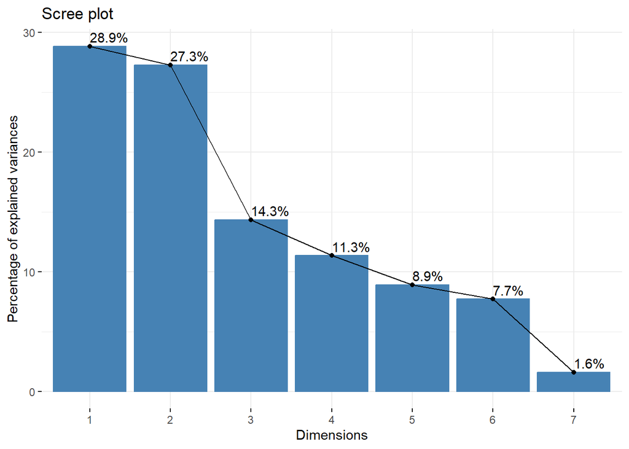

```r
fviz_eig(sc_dataset_pca, addlabels = TRUE)
```

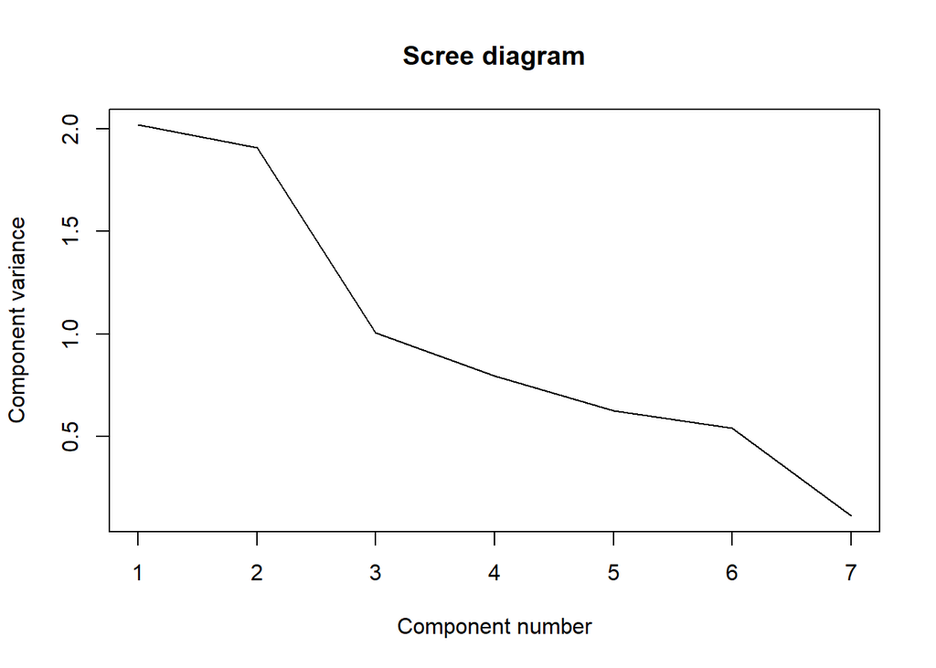

```r
plot(eigen_sc_dataset, xlab = "Component number", ylab = "Component variance", type = "l", main = "Scree diagram")
```

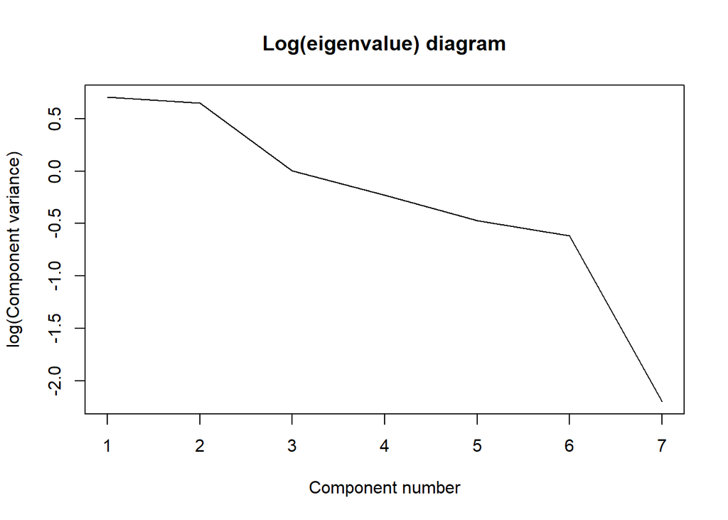

```r
plot(log(eigen_sc_dataset), xlab = "Component number",ylab = "log(Component variance)", type="l",main = "Log(eigenvalue) diagram")
```

• PC1 accounts for 28.85% of the total variance, PC2 for 27.26%, and subsequent components account for decreasing proportions of variance.

• The cumulative proportion of variance explained by the principal components indicates how much of the total variance in the dataset is captured by each successive component.

• In this case, the first two components capture over 56% of the total variance, while the first three components capture over 70.5%.

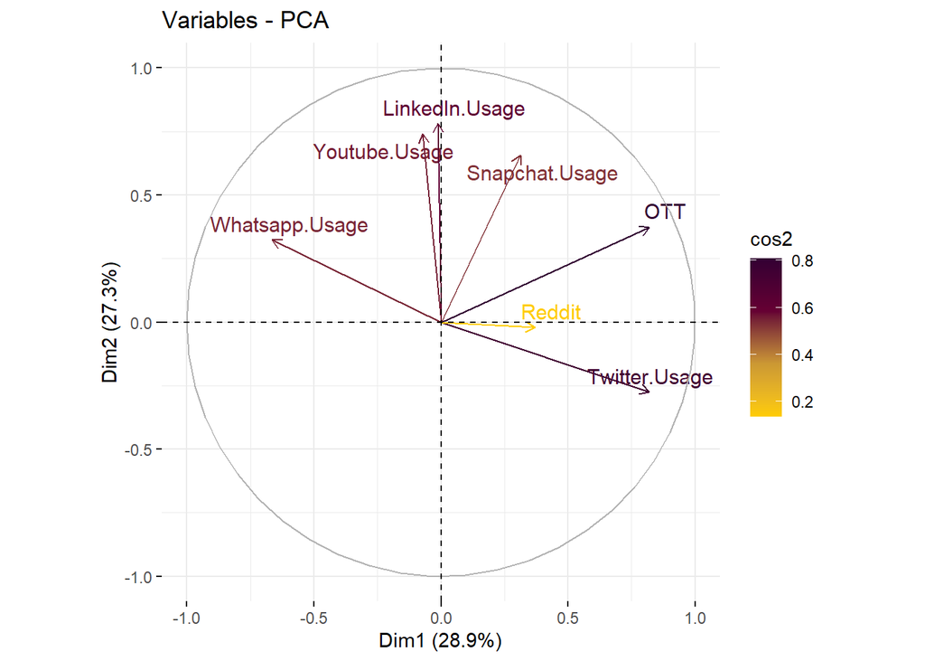

```r
fviz_pca_var(sc_dataset_pca,col.var = "cos2",
             gradient.cols = c("#FFCC00", "#CC9933", "#660033", "#330033"),
             repel = TRUE)
```

This visualization helps interpret how different social media variables contribute to the principal components identified through PCA, with the color indicating the strength of their contribution and the position in the scatterplot revealing their relationships with each other and with the principal components.

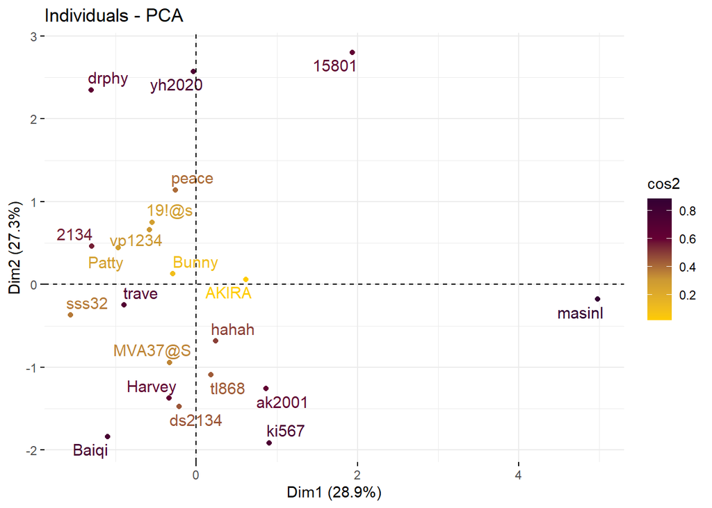

```r
fviz_pca_ind(sc_dataset_pca, col.ind = "cos2",
             gradient.cols = c("#FFCC00", "#CC9933", "#660033", "#330033"),
             repel = TRUE)
```

Each dot in the scatter plot represents a single individual. The position of a dot on the horizontal axis (Dim1) and the vertical axis (Dim2) reflects their scores on the two main categories, or principal components, identified by PCA.

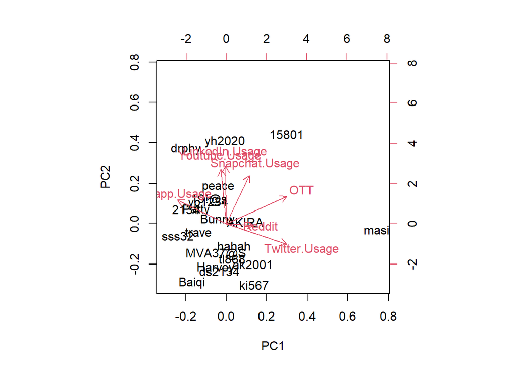

```r
biplot(sc_dataset_pca)
```

This combines above two plots into one.

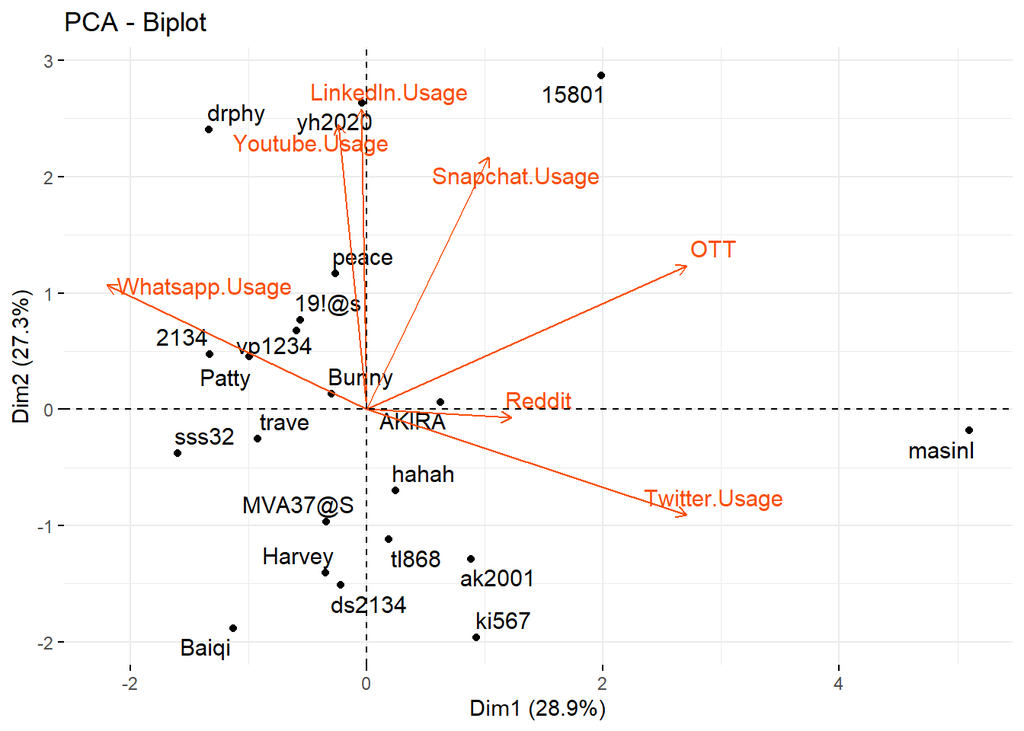

```r
fviz_pca_biplot(res.pca, repel = TRUE,
                col.var = "#FC4E07",
                )
```

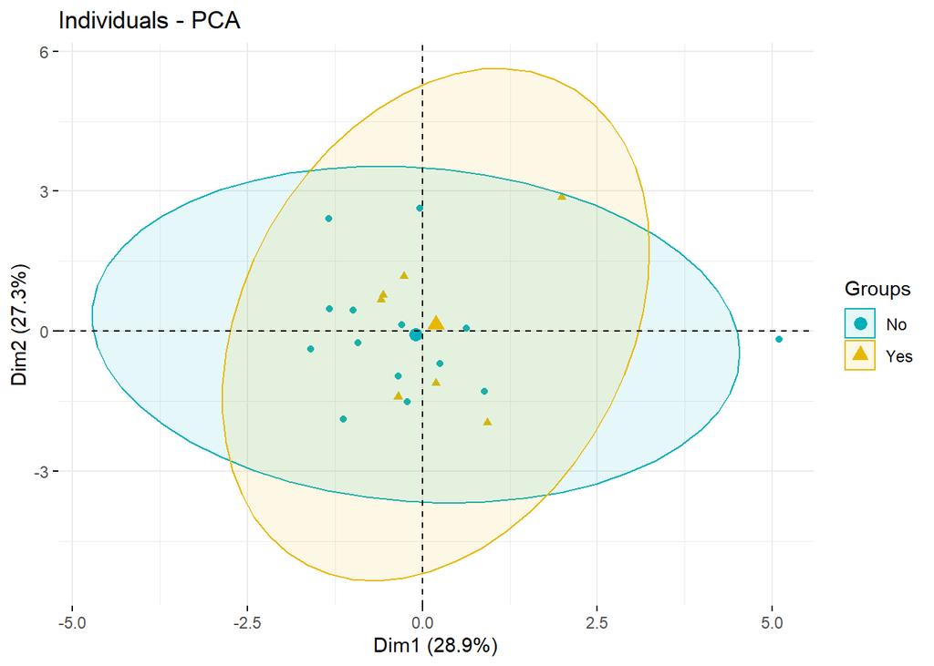

```r
fviz_pca_ind(res.pca,
             geom.ind = "point", # show points only (nbut not "text")
             col.ind = sc_dataset$Trouble_falling_asleep, # color by groups
             palette = c("#00AFBB", "#E7B800", "#FC4E07"),
             addEllipses = TRUE, # Concentration ellipses
             legend.title = "Groups"
)
```

This visualization helps to understand how individuals with different levels of “Trouble falling asleep” are distributed in the principal component space, potentially revealing any patterns or associations between social media usage and sleep-related issues.

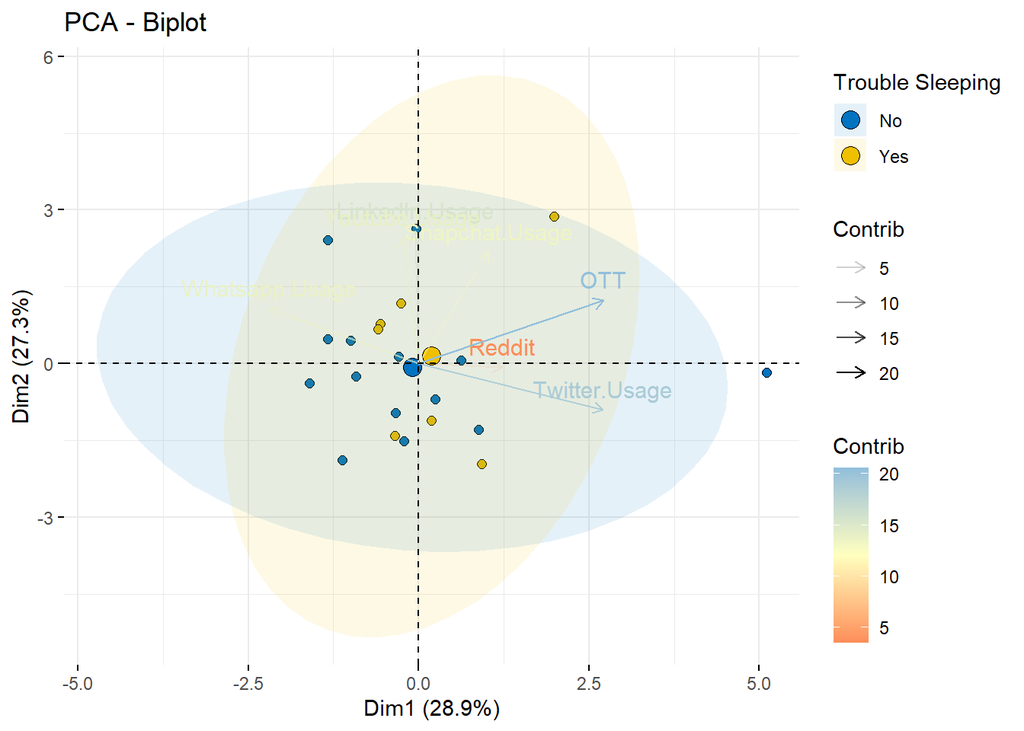

```r
fviz_pca_biplot(res.pca,
                # Individuals
                geom.ind = "point",
                fill.ind = sc_dataset$Trouble_falling_asleep, col.ind = "black",
                pointshape = 21, pointsize = 2,
                palette = "jco",
                addEllipses = TRUE,
                # Variables
                alpha.var ="contrib", col.var = "contrib",
                gradient.cols = "RdYlBu",

                legend.title = list(fill = "Trouble Sleeping", color = "Contrib",
                                    alpha = "Contrib")
)
```

This biplot visualizes a PCA analysis where the data points represent individuals and the variables might be related to sleep or sleep troubles. The coloring and transparency of the points and variable shapes will likely help identify which variables are most highly correlated with the principal components (Dim1 and Dim2) and how sleep troubles are positioned relative to those components.

While PCA identifies linear combinations of variables that explain the maximum amount of variance, FA goes a step further by attempting to identify the underlying latent factors that explain the observed correlations between variables. This can provide more interpretable results by uncovering the theoretical constructs that drive the observed patterns in the data.

# FACTOR ANALYSIS

```r
#FACTOR ANALYSIS

fit.pc <- principal(sc_dataset[,1:8][-1], nfactors=4, rotate="varimax")
fit.pc
```

```
## Principal Components Analysis
## Call: principal(r = sc_dataset[, 1:8][-1], nfactors = 4, rotate = "varimax")
## Standardized loadings (pattern matrix) based upon correlation matrix
##                  RC1   RC2   RC4   RC3   h2    u2 com
## LinkedIn.Usage  0.04  0.81  0.18 -0.08 0.69 0.310 1.1
## Snapchat.Usage  0.04  0.20  0.96 -0.02 0.96 0.037 1.1
## Twitter.Usage   0.95 -0.12 -0.21  0.06 0.96 0.043 1.1
## Whatsapp.Usage -0.57  0.50 -0.31 -0.01 0.67 0.329 2.5
## Youtube.Usage  -0.05  0.79  0.12  0.07 0.64 0.360 1.1
## OTT             0.75  0.27  0.39  0.17 0.82 0.182 1.9
## Reddit          0.11 -0.01 -0.01  0.99 0.99 0.012 1.0
##
##                        RC1  RC2  RC4  RC3
## SS loadings           1.80 1.65 1.26 1.02
## Proportion Var        0.26 0.24 0.18 0.15
## Cumulative Var        0.26 0.49 0.67 0.82
## Proportion Explained  0.31 0.29 0.22 0.18
## Cumulative Proportion 0.31 0.60 0.82 1.00
##
## Mean item complexity =  1.4
## Test of the hypothesis that 4 components are sufficient.
##
## The root mean square of the residuals (RMSR) is  0.09
##  with the empirical chi square  6.76  with prob <  NA
##
## Fit based upon off diagonal values = 0.89
```

```r
round(fit.pc$values, 3)
```

```
## [1] 2.020 1.908 1.004 0.794 0.624 0.540 0.111
```

```r
fit.pc$loadings
```

```
##
## Loadings:
##                RC1    RC2    RC4    RC3
## LinkedIn.Usage         0.806  0.180
## Snapchat.Usage         0.205  0.958
## Twitter.Usage   0.947 -0.115 -0.206
## Whatsapp.Usage -0.567  0.505 -0.307
## Youtube.Usage          0.786  0.119
## OTT             0.749  0.270  0.392  0.173
## Reddit          0.115                0.987
##
##                  RC1   RC2   RC4   RC3
## SS loadings    1.799 1.651 1.256 1.020
## Proportion Var 0.257 0.236 0.179 0.146
## Cumulative Var 0.257 0.493 0.672 0.818
```

```r
# Communalities
fit.pc$communality
```

```
## LinkedIn.Usage Snapchat.Usage  Twitter.Usage Whatsapp.Usage  Youtube.Usage
##      0.6902646      0.9625791      0.9570253      0.6705755      0.6398784
##            OTT         Reddit
##      0.8175810      0.9877495
```

```r
fit.pc$scores
```

```
##                 RC1          RC2         RC4         RC3
## masinl   3.78041462  0.384372410 -0.34218864  0.88527990
## peace   -0.45520913  0.260564522  1.12717155 -0.36681875
## Patty   -0.33133012  0.706265103 -0.62048001 -0.41164132
## Bunny   -0.16933344 -0.007257446  0.17108856 -0.39194585
## tl868    0.01679324 -0.768573250 -0.25563023  0.41609084
## drphy   -0.29239817  2.563674153 -1.04760938 -0.18621698
## trave   -0.39533679  0.085437049 -0.56071839 -0.32165239
## 19!@s   -0.56776555  0.189059984  0.67022503 -0.23493676
## yh2020  -0.05774564  1.548561726  1.04279916 -0.51535117
## ds2134  -0.22226743 -1.233144545 -0.04898053 -0.23137450
## ki567    0.91400513 -1.233330280 -0.50179274 -0.58952044
## ak2001   1.05535246 -0.494621109 -0.80451938 -0.52168894
## Harvey  -0.42434408 -1.345848667  0.26429683 -0.30554707
## hahah    0.26621117 -0.530796630 -0.03390555 -0.42313735
## AKIRA   -0.82221806 -0.095738973  0.12604182  4.12387587
## vp1234  -0.17819017  0.781866774 -0.41523824 -0.12217152
## sss32   -0.78677501  0.272092101 -1.11483869 -0.01786559
## MVA37@S -0.43362333 -1.039971947  0.35683961 -0.24423275
## 2134    -0.55156676  0.844153837 -0.86342355 -0.19171481
## 15801    0.40518281  0.399233330  3.40584648 -0.14374483
## Baiqi   -0.74985575 -1.285998143 -0.55498373 -0.20568560
```

```r
# Play with FA utilities
```

Variables with higher absolute loadings on a particular factor are more strongly associated with that factor. For instance, Twitter.Usage has a high loading on the first factor (RC1), suggesting that this factor represents usage patterns related to Twitter. Similarly, OTT has high loadings on multiple factors, indicating its association with different underlying constructs.

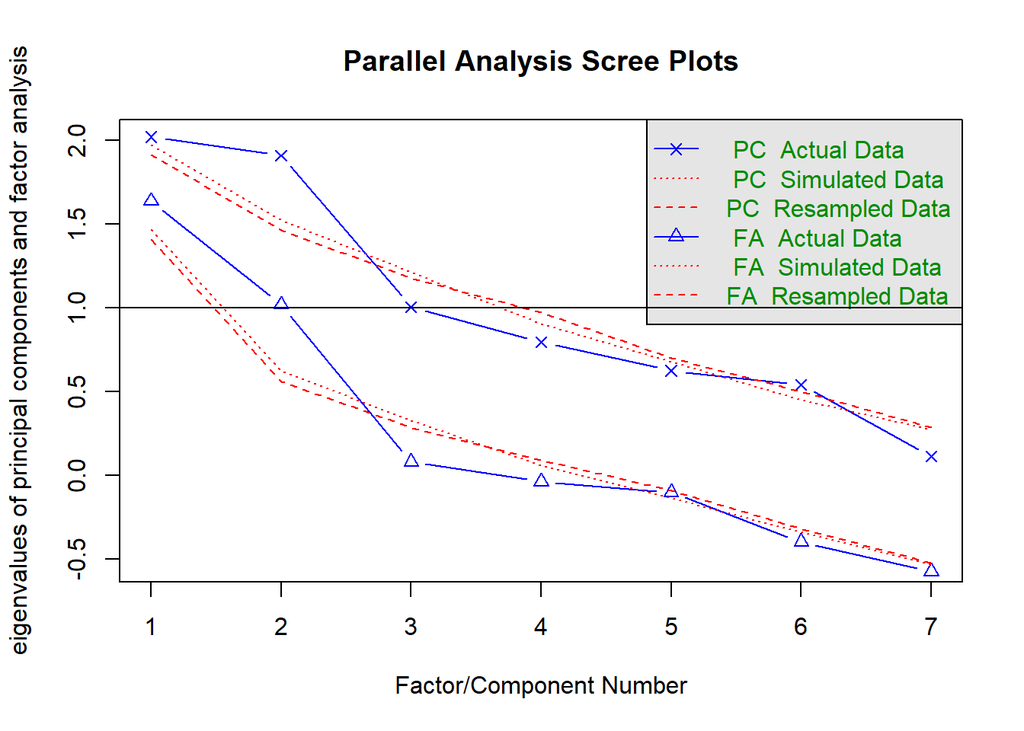

```
## Parallel analysis suggests that the number of factors =  2  and the number of components =  0
```

```r
fa.parallel(sc_dataset[,1:8][-1]) # See factor recommendation
```

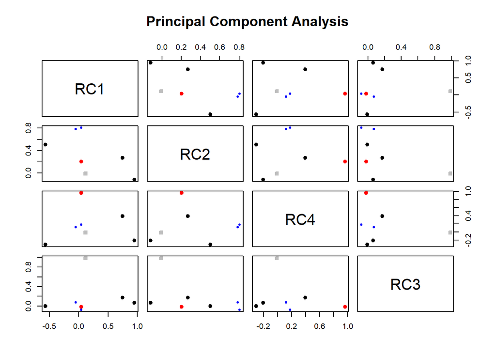

```r
fa.plot(fit.pc) # See Correlations within Factors
```

[figure not shown]

```r
fa.diagram(fit.pc) # Visualize the relationship
```

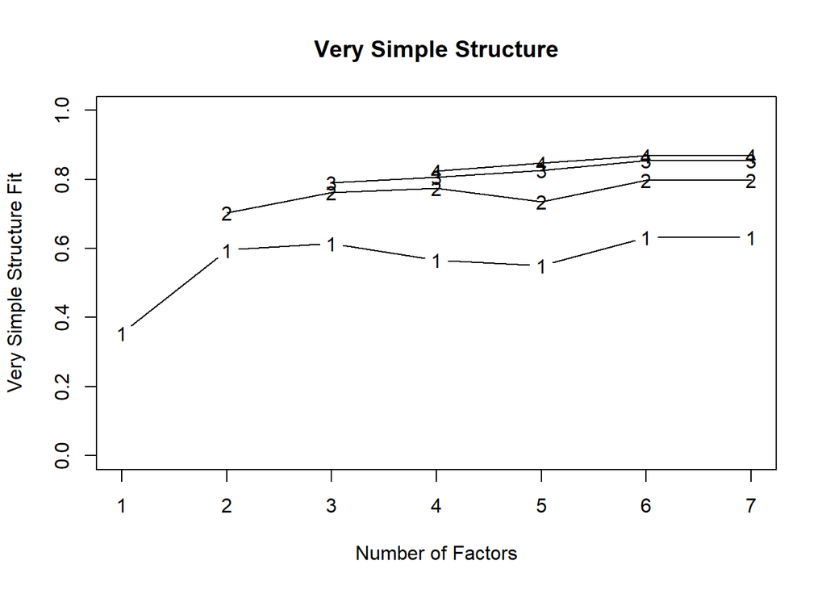

```
##
## Very Simple Structure
## Call: vss(x = sc_dataset[, 1:8][-1])
## Although the VSS complexity 1 shows  6  factors, it is probably more reasonable to think about  3  factors
## VSS complexity 2 achieves a maximimum of 0.8  with  6  factors
##
## The Velicer MAP achieves a minimum of 0.11  with  1  factors
## BIC achieves a minimum of  -19.91  with  1  factors
## Sample Size adjusted BIC achieves a minimum of  2.95  with  3  factors
##
## Statistics by number of factors
##   vss1 vss2  map dof   chisq  prob sqresid  fit RMSEA   BIC SABIC complex
## 1 0.35 0.00 0.11  14 2.3e+01 0.065     6.5 0.35  0.17 -19.9  23.3     1.0
## 2 0.60 0.70 0.11   8 1.0e+01 0.241     3.0 0.70  0.11 -14.0  10.7     1.2
## 3 0.62 0.76 0.21   3 2.8e+00 0.420     2.1 0.79  0.00  -6.3   2.9     1.4
## 4 0.57 0.78 0.25  -1 2.4e-01    NA     1.8 0.82    NA    NA    NA     1.5
## 5 0.55 0.74 0.46  -4 9.6e-09    NA     1.4 0.86    NA    NA    NA     1.5
## 6 0.63 0.80 1.00  -6 7.3e-12    NA     1.2 0.88    NA    NA    NA     1.5
## 7 0.63 0.80   NA  -7 6.9e-12    NA     1.2 0.88    NA    NA    NA     1.5
##    eChisq    SRMR eCRMS  eBIC
## 1 3.2e+01 1.9e-01 0.235 -10.2
## 2 4.4e+00 7.1e-02 0.115 -19.9
## 3 7.5e-01 2.9e-02 0.077  -8.4
## 4 1.1e-01 1.1e-02    NA    NA
## 5 1.9e-09 1.5e-06    NA    NA
## 6 6.0e-13 2.6e-08    NA    NA
## 7 6.0e-13 2.6e-08    NA    NA
```

```r
vss(sc_dataset[,1:8][-1]) # See Factor recommendations for a simple structure
```

Factor analysis revealed four latent factors (RC1, RC2, RC3, and RC4) derived from the social media dataset.

• RC2 reflects platforms oriented towards learning and professional networking, exemplified by YouTube and LinkedIn.

# CLUSTER ANALYSIS

Cluster analysis of the provided social media dataset enables the identification of distinct user segments based on their usage patterns across various platforms, facilitating a deeper understanding of user behavior and preferences.

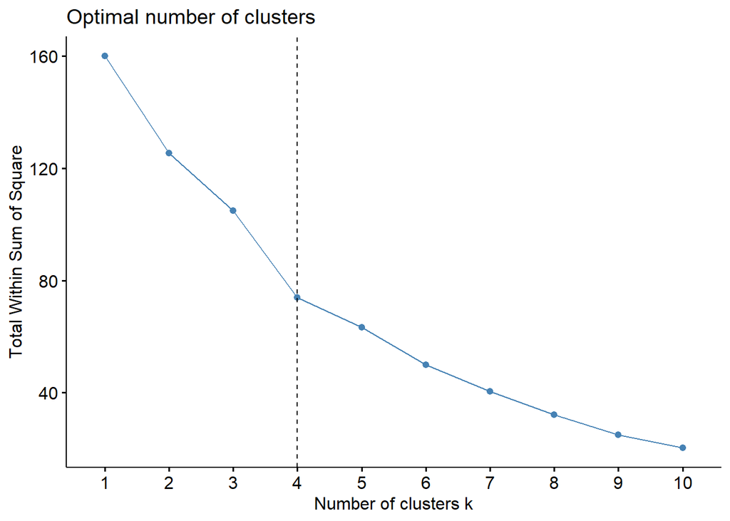

```r
#CLUSTER ANALYSIS

matstd.sc_dataset <- scale(sc_dataset[,1:8])
sc_dataset_scaled <- scale(sc_dataset[,1:8])

# Creating a (Euclidean) distance matrix of the standardized data
dist.sc_dataset <- dist(matstd.sc_dataset, method="euclidean")

fviz_nbclust(matstd.sc_dataset, kmeans, method ="wss")+geom_vline(xintercept = 4, linetype = 2)
```

• By selecting four clusters, we aim to strike a balance between maximizing the homogeneity within clusters while minimizing the complexity of the segmentation.

• With four clusters, we can effectively group users with similar usage patterns and behaviors.

```r
# Hierarchial Clusiering
res.hc <- matstd.sc_dataset %>% scale() %>% dist(method = "euclidean") %>%
  hclust(method = "ward.D2")

# Lets see what the optimal numbers of clusers are
# Compute

res.nbclust <- sc_dataset[,1:8] %>% scale() %>% NbClust(distance = "euclidean", min.nc = 3, max.nc = 13, method = "complete", index ="all")
```

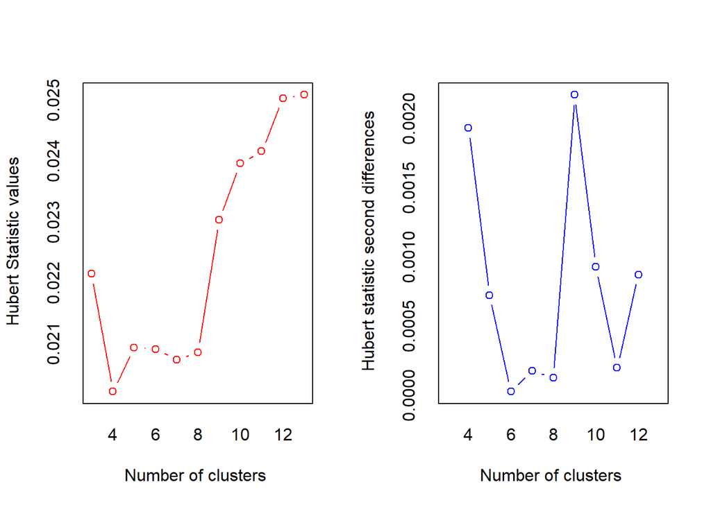

```
## *** : The Hubert index is a graphical method of determining the number of clusters.
##                 In the plot of Hubert index, we seek a significant knee that corresponds to a
##                 significant increase of the value of the measure i.e the significant peak in Hubert
##                 index second differences plot.
##
```

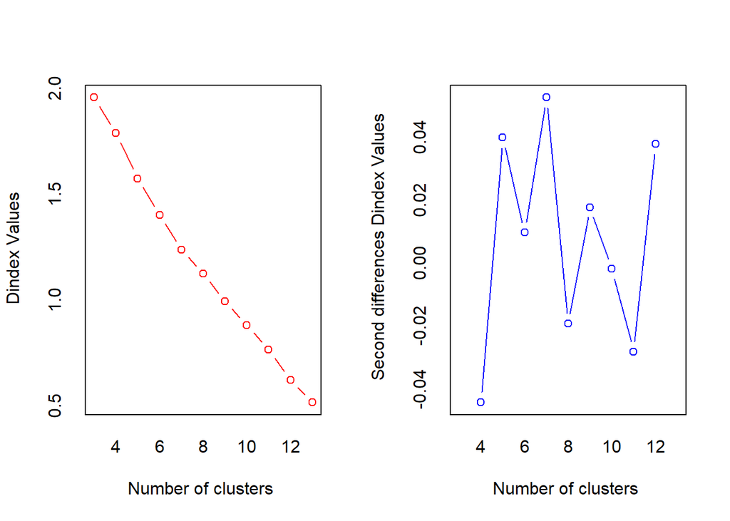

```
## *** : The D index is a graphical method of determining the number of clusters.
##                 In the plot of D index, we seek a significant knee (the significant peak in Dindex
##                 second differences plot) that corresponds to a significant increase of the value of
##                 the measure.
##
## * Among all indices:
## * 9 proposed 3 as the best number of clusters
## * 2 proposed 4 as the best number of clusters
## * 2 proposed 5 as the best number of clusters
## * 2 proposed 6 as the best number of clusters
## * 4 proposed 12 as the best number of clusters
## * 5 proposed 13 as the best number of clusters
##
##                    ***** Conclusion *****
##
## * According to the majority rule, the best number of clusters is  3
##
##
```

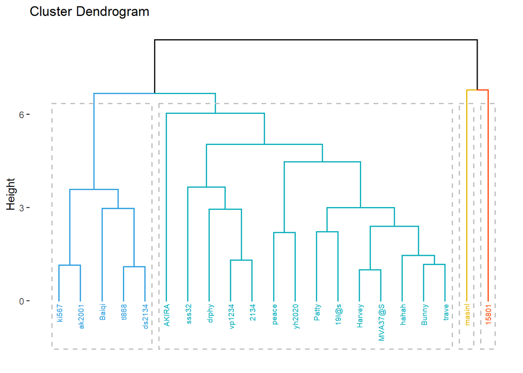

```r
fviz_dend(res.hc, k = 4, # Cut in four groups
          cex = 0.5, # label size
          k_colors = c("#2E9FDF", "#00AFBB", "#E7B800", "#FC4E07"),
          color_labels_by_k = TRUE, # color labels by groups
          rect = TRUE # Add rectangle around groups
)
```

• There are around 20 items or observations in the dataset.

• These items have been grouped into approximately 4 clusters.

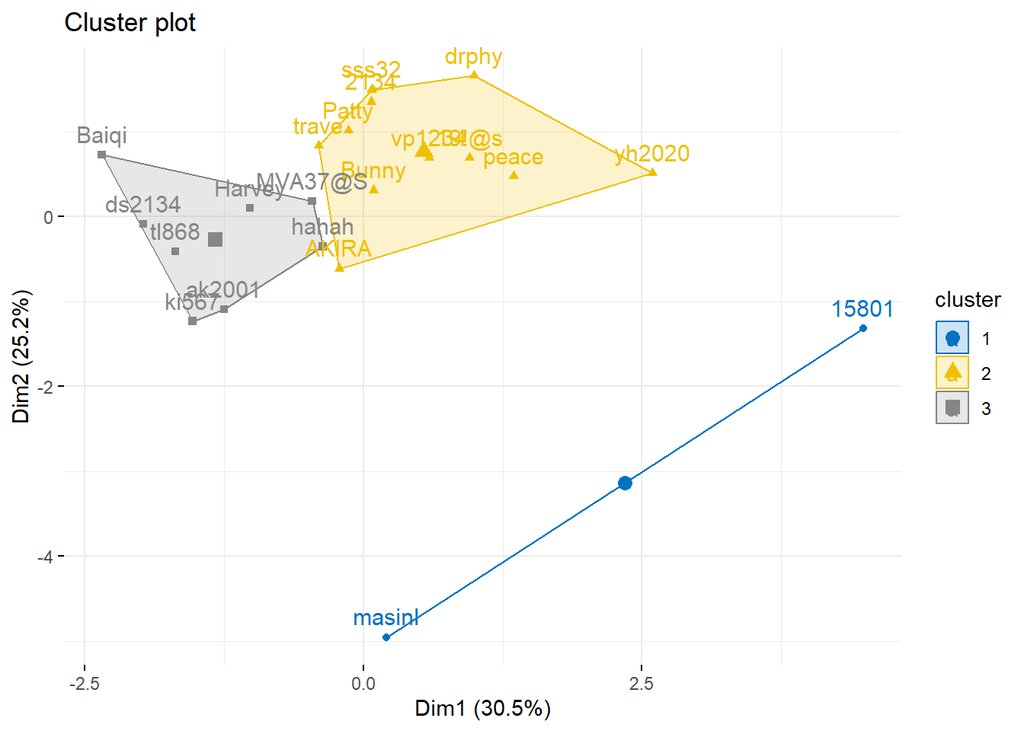

```r
set.seed(123)
km.res <- kmeans(matstd.sc_dataset, 3, nstart = 25)
# Visualize
fviz_cluster(km.res, data = matstd.sc_dataset, ellipse.type = "convex",palette = "jco",ggtheme = theme_minimal())
```

• The visualization of these clusters using fviz_cluster reveals the grouping of users into different segments characterized by their respective social media usage behaviors.

• Each cluster, represented by ellipses, showcases the concentration of users with similar usage tendencies within the feature space defined by the standardized social media usage variables.

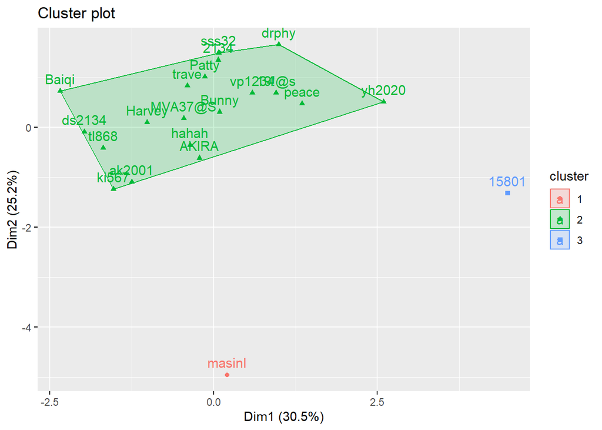

```r
# If your data has outliears , use PAM method
pam.res <- pam(matstd.sc_dataset, 3)
# Visualize
fviz_cluster(pam.res)
```

• The Partitioning Around Medoids (PAM) clustering method is particularly suitable for datasets with outliers as it employs representative points (medoids) instead of means for cluster assignment.

• In this context, the PAM algorithm was applied to the standardized social media dataset to create three clusters based on the medoids.

• As shown, 15801 and masinl are the outliers in our dataset.

# MY DATA COMPARED TO OTHERS:

Z-scores allow us to understand how each student’s social media usage compares to the overall distribution of usage for each platform. Positive z-scores indicate values above the mean, while negative z-scores indicate values below the mean.

```r
social_media_data1 <- read.csv("/Users/parul/OneDrive/Desktop/MVA/Midterm_Final.csv")

# Select the columns containing social media usage data
social_media_data1 <- sc_dataset[,1:8][, -1]  # Exclude the first column

# Calculate mean and standard deviation for each social media variable
means <- colMeans(social_media_data1)
std_devs <- apply(social_media_data1, 2, sd)

# Calculate z-scores for each student
z_scores <- scale(social_media_data1, center = means, scale=std_devs)

print(z_scores)
```

```
##         LinkedIn.Usage Snapchat.Usage Twitter.Usage Whatsapp.Usage
## masinl      0.19809978    -0.11764463     3.5602189    -1.36367696
## peace       0.64057906     1.24482558    -0.4297799    -0.46966228
## Patty       1.38331213    -0.50207606    -0.4297799     1.07977152
## Bunny       0.66823401    -0.01588337    -0.4297799    -0.16207524
## tl868      -1.24390858    -0.68298497    -0.1105800    -0.78874791
## drphy       1.38331213    -0.52468968    -0.4297799     1.79843283
## trave       0.19809978    -0.68298497    -0.4297799     0.07364567
## 19!@s       0.19809978     1.01303605    -0.4297799     1.22350378
## yh2020      2.56852448     1.29570621    -0.4297799     0.09951748
## ds2134     -1.38218336    -0.68298497    -0.4297799    -1.36367696
## ki567      -0.56043613    -0.54164989     1.3657196    -1.36367696
## ak2001     -0.47352055    -0.56991690     1.5652195    -0.67376209
## Harvey     -0.78167576    -0.10633783    -0.4297799    -0.49553409
## hahah      -0.19697100    -0.11764463     0.3682199    -0.71688177
## AKIRA      -0.01918915     0.02369045    -0.4297799     0.15988503
## vp1234      0.59317056    -0.54164989    -0.4297799    -0.21381885
## sss32      -1.19254938    -0.68298497    -0.3020999     2.14626491
## MVA37@S    -0.76982364     0.17633234    -0.4297799     0.23750045
## 2134        0.02031793    -0.68298497    -0.4297799     0.80668022
## 15801       0.02821934     3.38181207    -0.4297799    -0.72838035
## Baiqi      -1.25971141    -0.68298497    -0.4297799     0.71469157
##         Youtube.Usage          OTT     Reddit
## masinl    -0.22115515  3.443554754  1.2459494
## peace      0.71679173 -0.653192355 -0.3230682
## Patty     -0.78392328 -0.088123788 -0.3230682
## Bunny     -0.50538148 -0.088123788 -0.3230682
## tl868      0.23360697 -0.088123788  0.3045388
## drphy      2.33688179  0.194410495 -0.3230682
## trave      0.06307118 -0.653192355 -0.3230682
## 19!@s     -0.50538148  0.194410495 -0.3230682
## yh2020     0.63152383  0.194410495 -0.3230682
## ds2134     0.06307118 -0.653192355 -0.3230682
## ki567     -1.07383413 -0.653192355 -0.3230682
## ak2001    -0.33484568 -0.285897787 -0.3230682
## Harvey    -1.33532235 -0.509099871 -0.3167921
## hahah     -0.33484568 -0.370658072 -0.3230682
## AKIRA      0.10854739 -0.215264216  4.0701809
## vp1234     1.19997648 -0.370658072 -0.1347861
## sss32      0.24497602 -0.254819016 -0.3230682
## MVA37@S   -1.36942951 -0.009014189 -0.3230682
## 2134       1.25113722 -0.653192355 -0.3230682
## 15801      1.25682175  2.172150479 -0.3230682
## Baiqi     -1.64228678 -0.653192355 -0.3230682
## attr(,"scaled:center")
## LinkedIn.Usage Snapchat.Usage  Twitter.Usage Whatsapp.Usage  Youtube.Usage
##      3.4985714      1.2080952      0.5385714      5.7438095      2.8890476
##            OTT         Reddit
##      2.3119048      0.5147619
## attr(,"scaled:scale")
## LinkedIn.Usage Snapchat.Usage  Twitter.Usage Whatsapp.Usage  Youtube.Usage
##       2.531192       1.768846       1.253133       3.478690       1.759161
##            OTT         Reddit
##       3.539393       1.593354
```

For me - “drphy”, the z-scores for various social media platforms are as follows:

LinkedIn Usage: 1.38331213

Snapchat Usage: -0.52468968

Twitter Usage: -0.4297799

Whatsapp Usage: 1.79843283

Youtube Usage: 2.33688179

OTT: 0.194410495

Reddit: -0.3230682

Interpretation:

This indicates that I have above-average usage for LinkedIn, Whatsapp, Youtube, and OTT (Over-the-Top) platforms, as their z-scores are positive, indicating values above the mean. On the other hand, have below-average usage for Snapchat, Twitter, and Reddit, as their z-scores are negative, indicating values below the mean.

These z-scores provide a standardized measure for my social media usage relative to the mean usage of each platform among all students in the dataset.

# TAKE AWAY

Additionally, there are a few outliers within these groups, indicating students who exhibit extreme behavior by spending disproportionately more time on specific types of apps compared to their peers. The main lesson learned from this analysis is the need to decrease social media usage due to its potential impact on sleep and other aspects of our well-being. Below, I’ve outlined insights into how each platform can affect our sleep.

```r
library(dplyr)  # For data manipulation

# Load the dataset
social_media_data <- read.csv("/Users/parul/OneDrive/Desktop/MVA/Midterm_Final.csv")
# Remove irrelevant columns if any
social_media_data <- social_media_data[, -1]  # Assuming the first column is ID and not needed

# Check for missing values and handle them if necessary
# social_media_data <- na.omit(social_media_data)

# Separate data for individuals having trouble sleeping and those not having trouble sleeping
trouble_sleeping <- social_media_data %>% filter(Trouble_falling_asleep == "Yes")
no_trouble_sleeping <- social_media_data %>% filter(Trouble_falling_asleep == "No")

# Calculate the variance for each group
variance_trouble_sleeping <- apply(trouble_sleeping[, -9], 2, var)
variance_no_trouble_sleeping <- apply(no_trouble_sleeping[, -9], 2, var)

# Compare variances
comparison <- data.frame(
  Variable = colnames(social_media_data)[1:8],  # Assuming first 8 columns are variables
  Variance_Trouble_Sleeping = variance_trouble_sleeping,
  Variance_No_Trouble_Sleeping = variance_no_trouble_sleeping
)

# Print the comparison
print(comparison)
```

```
##                        Variable Variance_Trouble_Sleeping
## Instagram.Usage Instagram.Usage                20.3441286
## LinkedIn.Usage   LinkedIn.Usage                 3.3033476
## Snapchat.Usage   Snapchat.Usage                 6.8050667
## Twitter.Usage     Twitter.Usage                 0.7032143
## Whatsapp.Usage   Whatsapp.Usage                 7.8090619
## Youtube.Usage     Youtube.Usage                 3.4788238
## OTT                         OTT                12.5533476
## Reddit                   Reddit                 0.1408238
##                 Variance_No_Trouble_Sleeping
## Instagram.Usage                    7.2987258
## LinkedIn.Usage                     8.1983104
## Snapchat.Usage                     0.9408951
## Twitter.Usage                      2.0706747
## Whatsapp.Usage                    13.4084901
## Youtube.Usage                      3.1430066
## OTT                               13.4771670
## Reddit                             3.7541209
```

From the comparison results:

Instagram Usage: The variance of Instagram usage is higher among individuals having trouble sleeping compared to those not having trouble sleeping.

Twitter Usage: Interestingly, the variance of Twitter usage is much higher among individuals not having trouble sleeping compared to those having trouble sleeping.

OTT (Over-the-top media services): The variance of OTT usage is relatively similar between individuals having trouble sleeping and those not having trouble sleeping.